# analysis

```r
knitr::opts_chunk$set(warning = FALSE, message = FALSE)
#packages and custom functions
source("functions.R")
pacman::p_load(tidybayes, bayesplot, posterior, cmdstanr)
```

## plot posteriors

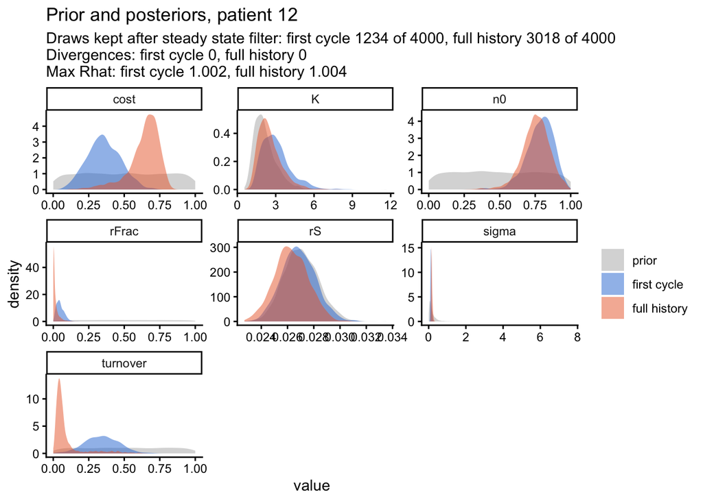

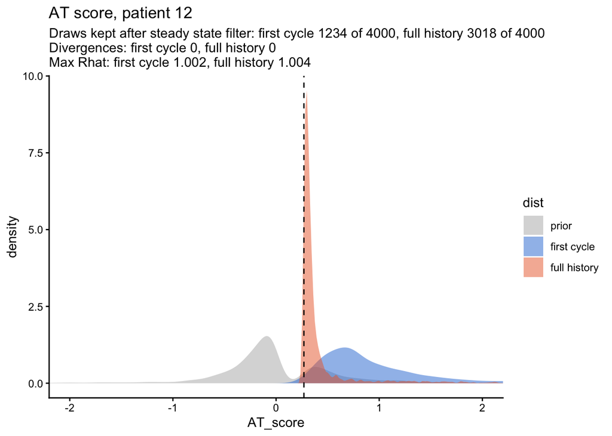

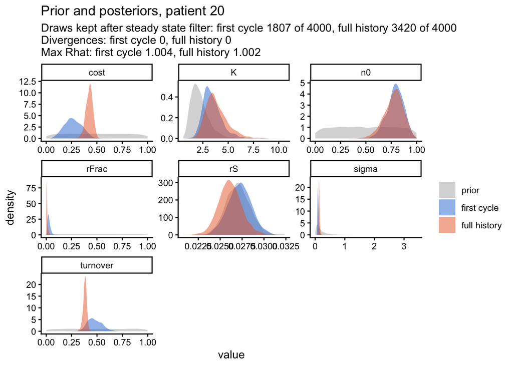

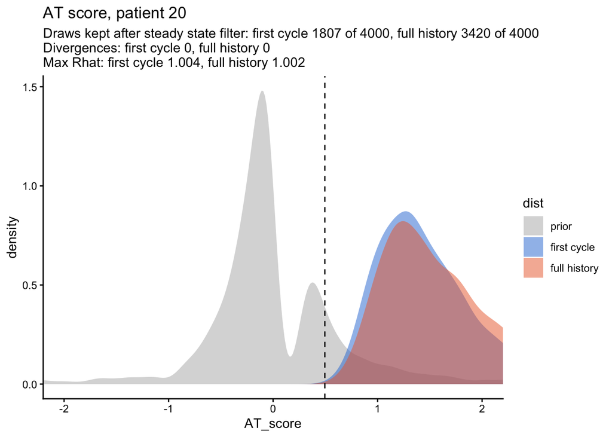

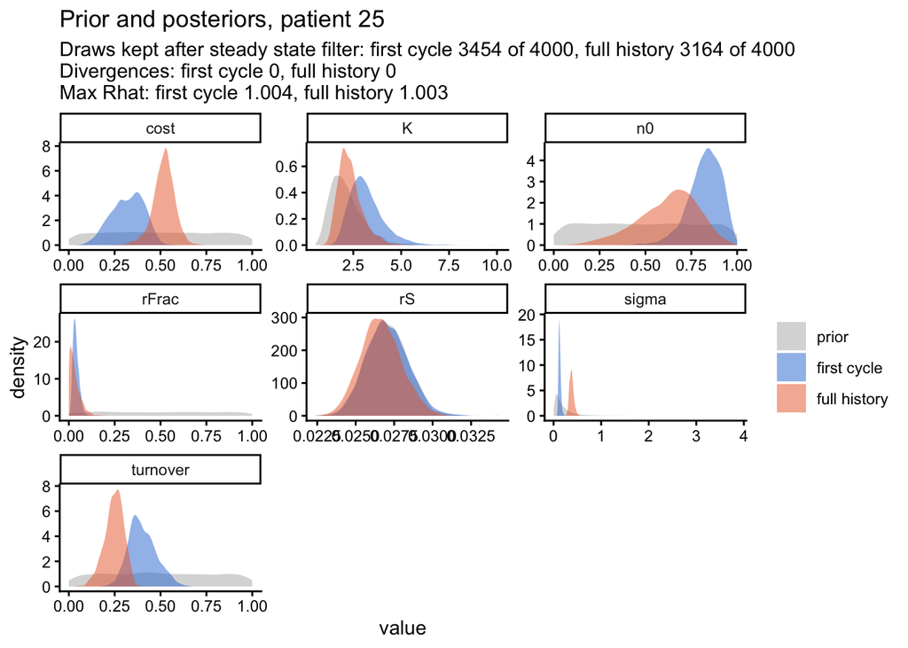

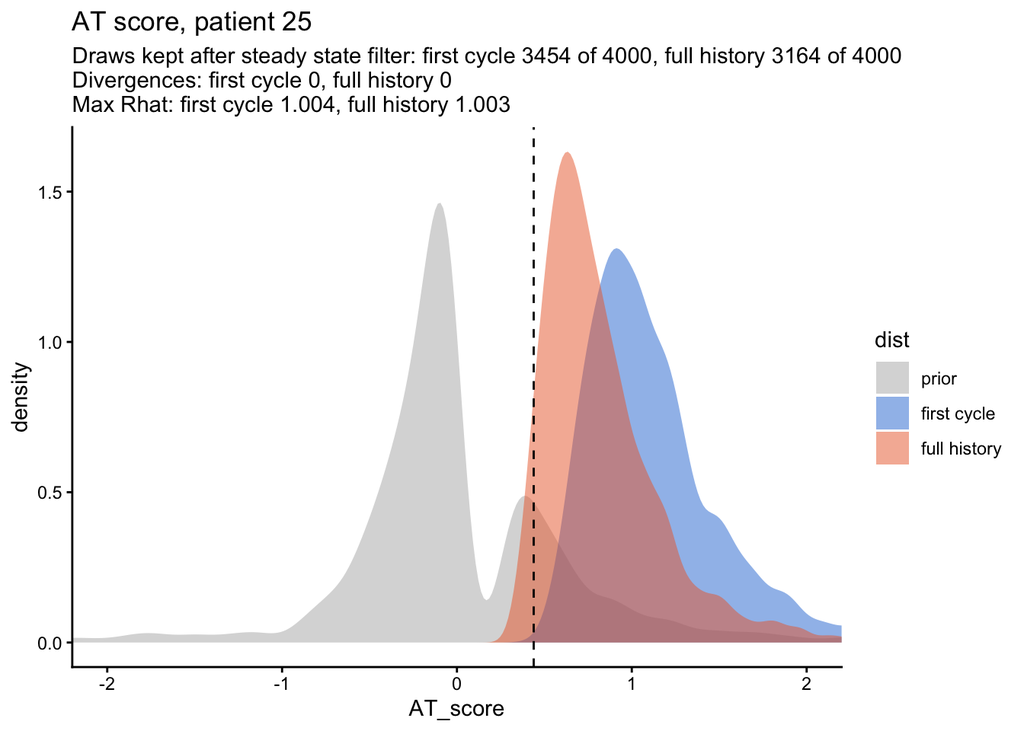

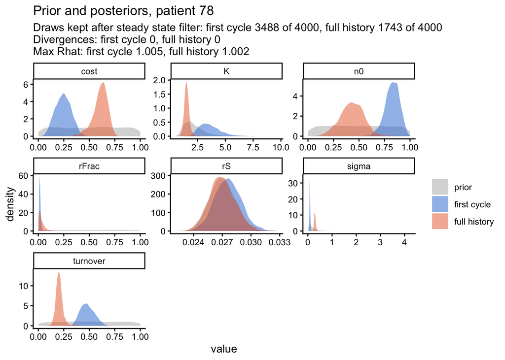

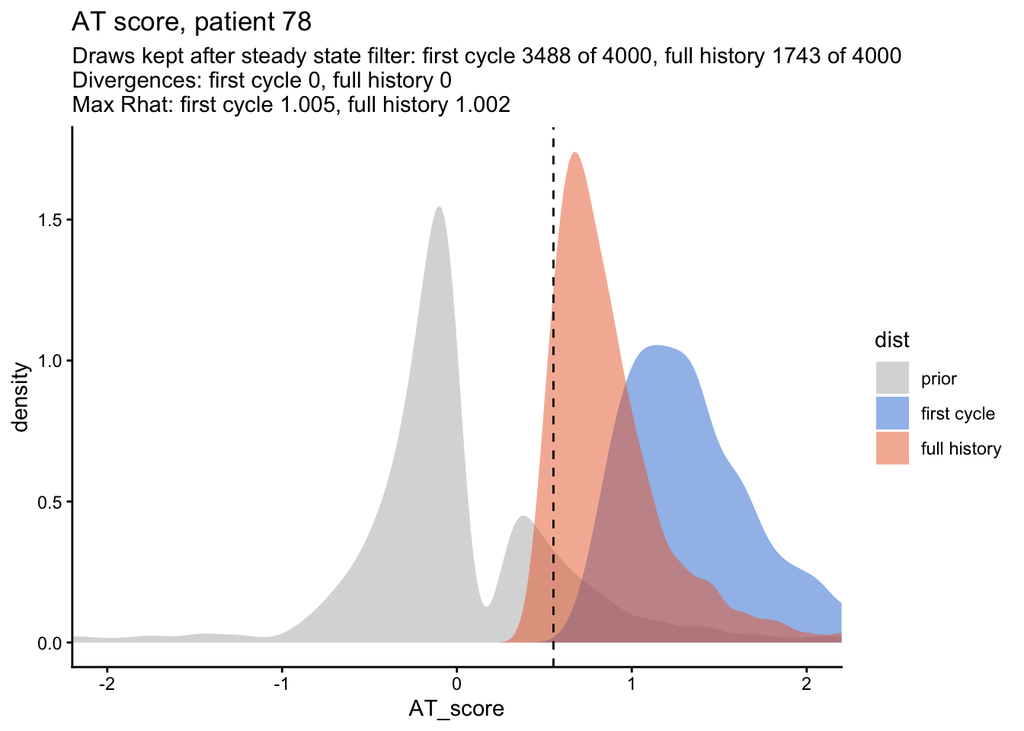

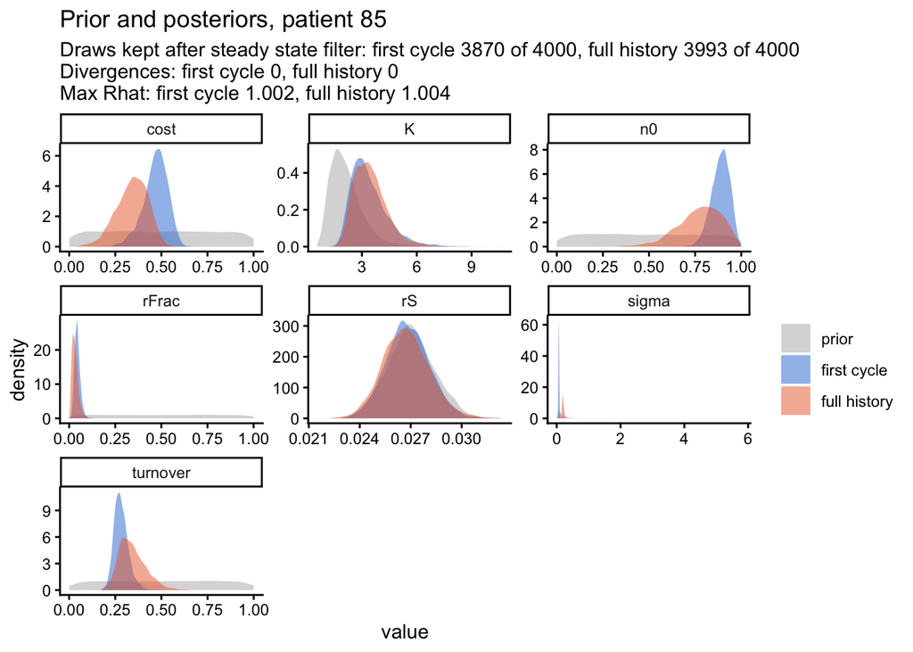

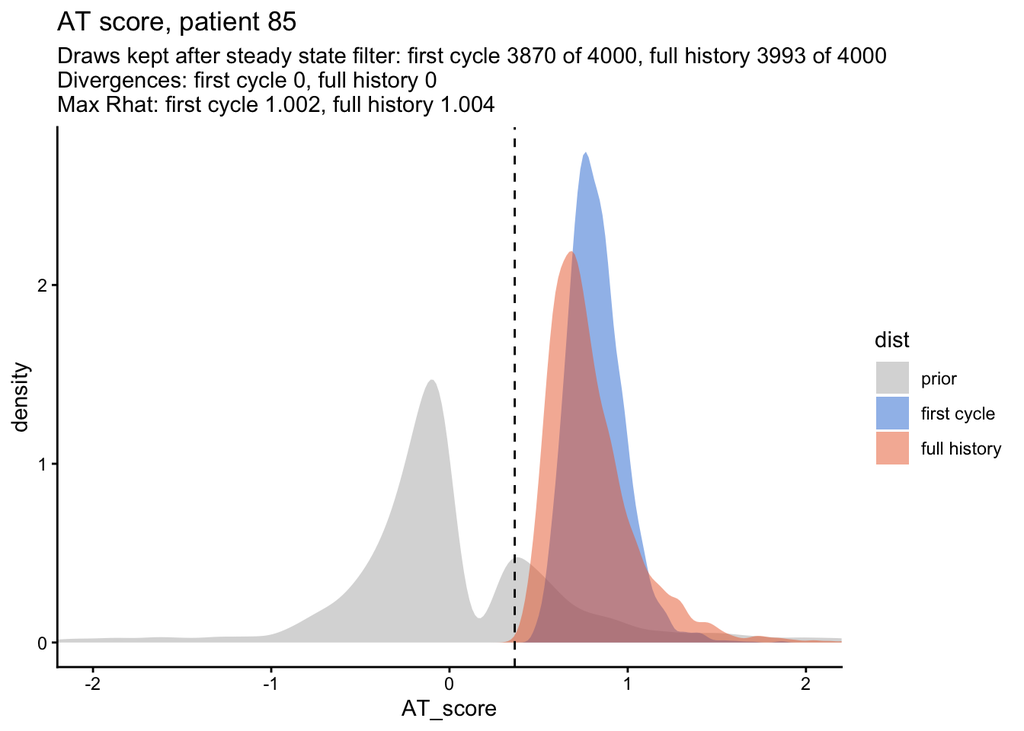

```r
#AT scores reported in the biomarker paper, drawn as a dashed line on the AT score plot
paper_at_scores <- tibble(patient = c(12, 20, 25, 78, 85),
                          AT_score = c(0.270, 0.495, 0.439, 0.552, 0.366),
                          ci_low   = c(0.259, 0.460, 0.410, 0.511, 0.353),
                          ci_high  = c(0.288, 0.546, 0.495, 0.666, 0.389))

#clauded up a function to plot posteriors versus priors
plot_prior_posterior <- function(patient_id, n = 4000, kappa = .2, filter_steady_state) {
  first_fit <- readRDS(make_fit_path(patient_id, here::here("fits/segmented_first_cycle")))
  full_fit  <- readRDS(make_fit_path(patient_id, here::here("fits/segmented_full_history")))

  prior_draws <- tibble(
    cost     = runif(n, 0, 1),
    turnover = runif(n, 0, 1),
    n0       = runif(n, 0, 1),
    rFrac    = runif(n, 0, 1),
    K        = rlnorm(n, log(2), .4),
    rS       = rlnorm(n, log(0.027), .05),
    sigma    = rlnorm(n, -2, 1)
  ) |>
    filter(K > n0) #stan bounds K below by n0

  params <- names(prior_draws)
  get_post <- function(fit) {
    fit$draws(params, format = "draws_df") |> as_tibble() |> select(all_of(params))
  }

  draws <- bind_rows(prior            = prior_draws,
                     `first cycle`    = get_post(first_fit),
                     `full history`   = get_post(full_fit),
                     .id = "dist") |>
    mutate(dist = factor(dist, c("prior", "first cycle", "full history")),
           #AT score from the same transforms as the stan model
           AT_score = calc_delta_benefit(kappa = kappa, dR = turnover * rS, K = K,
                                         rR = (1 - cost) * rS, R0 = rFrac * n0))

  #count posterior draws before and after filtering on eq. (8). The prior is left unfiltered
  n_before <- count(draws, dist, name = "before")
  if (filter_steady_state) draws <- filter(draws, dist == "prior" | turnover < (1-1.2*n0/K) * (1-cost) )
  n_after <- count(draws, dist, name = "after")
  draw_counts <- left_join(n_before, n_after, by = "dist") |> mutate(after = replace_na(after, 0L)) |>
    filter(dist != "prior")

  #number of divergent transitions in a fit
  n_div <- function(fit) sum(fit$diagnostic_summary(quiet = TRUE)$num_divergent)
  #largest rhat across the plotted parameters
  max_rhat <- function(fit) round(max(fit$summary(params, "rhat")$rhat, na.rm = TRUE), 3)

  fill_colours <- c("prior" = "grey70", "first cycle" = "#2a78d6", "full history" = "#eb6834")
  subtitle_text <- paste0(if (filter_steady_state) "Draws kept after steady state filter: " else "Draws: ",
                          paste(draw_counts$dist, paste(draw_counts$after, "of", draw_counts$before), collapse = ", "),
                          "\nDivergences: first cycle ", n_div(first_fit), ", full history ", n_div(full_fit),
                          "\nMax Rhat: first cycle ", max_rhat(first_fit), ", full history ", max_rhat(full_fit))

  #parameters
  params_plot <- draws |>
    select(-AT_score) |>
    pivot_longer(-dist, names_to = "parameter") |>
    ggplot(aes(value, fill = dist)) +
    geom_density(alpha = .5, colour = NA) +
    facet_wrap(~ parameter, scales = "free") +
    scale_fill_manual(values = fill_colours) +
    theme_classic() +
    labs(title = paste("Prior and posteriors, patient", patient_id), subtitle = subtitle_text, fill = NULL)

  #AT score, with the paper's value as a dashed line. Non-finite scores and scores outside [-4, 4] are left out
  at_plot <- draws |>
    filter(between(AT_score, -4, 4)) |>
    ggplot(aes(AT_score, fill = dist)) +
    geom_density(alpha = .5, colour = NA) +
    geom_vline(data = filter(paper_at_scores, patient == patient_id), aes(xintercept = AT_score), linetype = "dashed") +
    scale_fill_manual(values = fill_colours) +
    coord_cartesian(xlim = c(-2, 2)) +
    theme_classic() +
    labs(title = paste("AT score, patient", patient_id),
         subtitle = subtitle_text)

  list(params = params_plot, at = at_plot, draws = draws)
}

#median and 95% interval of the AT score per patient and fit, filled in by the loop
at_summaries <- list()
for (id in c(12, 20, 25, 78, 85)) {
  #skip patients that are missing either fit
  has_fits <- file.exists(make_fit_path(id, here::here("fits/segmented_first_cycle")),
                          make_fit_path(id, here::here("fits/segmented_full_history")))
  if (!all(has_fits)) next

  plots <- plot_prior_posterior(id, filter_steady_state = T)
  print(plots$params)
  print(plots$at)

  #non-finite AT scores (log of a negative number) are left out of the summary
  at_summaries[[as.character(id)]] <- plots$draws |>
    filter(dist != "prior", is.finite(AT_score)) |>
    group_by(dist) |>
    median_qi(AT_score) |>
    mutate(patient = id)
}
```

## AT scores versus paper

```r
at_table <- bind_rows(at_summaries) |>
  select(patient, fit = dist, AT_score, .lower, .upper) |>
  left_join(paper_at_scores, by = "patient", suffix = c("", "_paper")) |>
  mutate(paper_in_interval = between(AT_score_paper, .lower, .upper))

knitr::kable(at_table, digits = 3)
```

| patient | fit | AT_score | .lower | .upper | AT_score_paper | ci_low | ci_high | paper_in_interval |
| --- | --- | --- | --- | --- | --- | --- | --- | --- |
| 12 | first cycle | 0.798 | 0.314 | 4.318 | 0.270 | 0.259 | 0.288 | FALSE |
| 12 | full history | 0.316 | 0.264 | 2.691 | 0.270 | 0.259 | 0.288 | TRUE |
| 20 | first cycle | 1.439 | 0.785 | 3.931 | 0.495 | 0.460 | 0.546 | FALSE |
| 20 | full history | 1.535 | 0.828 | 4.987 | 0.495 | 0.460 | 0.546 | FALSE |
| 25 | first cycle | 1.044 | 0.606 | 2.190 | 0.439 | 0.410 | 0.495 | FALSE |
| 25 | full history | 0.749 | 0.400 | 1.921 | 0.439 | 0.410 | 0.495 | TRUE |
| 78 | first cycle | 1.291 | 0.772 | 2.636 | 0.552 | 0.511 | 0.666 | FALSE |
| 78 | full history | 0.792 | 0.477 | 2.253 | 0.552 | 0.511 | 0.666 | TRUE |
| 85 | first cycle | 0.808 | 0.570 | 1.179 | 0.366 | 0.353 | 0.389 | FALSE |
| 85 | full history | 0.740 | 0.479 | 1.460 | 0.366 | 0.353 | 0.389 | FALSE |

Median AT score is above the paper’s value in 10 of 10 fits. The paper’s value is inside our 95% interval in 3 of them. The full history fits sit closer to the paper than the first cycle fits for most patients.

## Freeing parameters one at a time, probing cycle

```r
probing_ids   <- c(12, 20, 25, 78, 85)
probing_fixed <- list(rS = 0.027, rFrac = 0.00001, cost = 0.1, dD = 1.5, n0 = 1)
free_order    <- c("n0", "rFrac","cost","dD", "rS" )

#fixed values for each step. Step 0 is the probing cycle fit, each step after frees one more parameter
steps <- map(0:length(free_order), \(i) probing_fixed[setdiff(names(probing_fixed), head(free_order, i))])
names(steps) <- c("0_probing", paste0(seq_along(free_order), "_free_", free_order))

#fits and their settings are saved per step. Saved fits are skipped, so this only fits what is missing
for (step in names(steps)) {
  fit_patients(probing_ids, stan_file = here::here("stan/model_switchable.stan"), priors = make_priors(),
               fixed_vals = steps[[step]], first_cycle = TRUE,
               out_dir = here::here("fits/probing_cycle", step),
               chains = 4, parallel_chains = 4, seed = 1, refresh = 500, adapt_delta = .95)
}
```

```r
#results hidden because generate_quantities prints cmdstan progress
params <- c("cost", "turnover", "n0", "rFrac", "K", "rS", "dD", "sigma")

#prior draws from a saved priors list. Fixed parameters take their fixed value and K is kept above n0 like in stan
draw_prior <- function(priors, fixed_vals, n = 4000) {
  tibble(
    cost     = runif(n, priors$cost_prior[1], priors$cost_prior[2]),
    turnover = runif(n, priors$turnover_prior[1], priors$turnover_prior[2]),
    n0       = runif(n, priors$n0_prior[1], priors$n0_prior[2]),
    rFrac    = runif(n, priors$rFrac_prior[1], priors$rFrac_prior[2]),
    K        = rlnorm(n, priors$K_prior[1], priors$K_prior[2]),
    rS       = rlnorm(n, priors$rS_prior[1], priors$rS_prior[2]),
    dD       = rlnorm(n, priors$dD_prior[1], priors$dD_prior[2]),
    sigma    = rlnorm(n, priors$sigma_prior[1], priors$sigma_prior[2])
  ) |>
    mutate(!!!fixed_vals) |>
    filter(K > n0)
}

#posterior draws, AT score, diagnostics and settings for the saved fits in a step
read_step <- function(step, step_dir = here::here("fits/probing_cycle", step)) {
  ids <- probing_ids[file.exists(make_fit_path(probing_ids, step_dir))] #missing means the fit failed
  if (!length(ids)) return(NULL)
  fits <- map(ids, \(id) readRDS(make_fit_path(id, step_dir)))

  draws <- map2_dfr(fits, ids, \(fit, id) fit$draws(params, format = "draws_df") |> as_tibble() |>
                      select(all_of(params)) |> mutate(patient = id)) |>
    mutate(AT_score     = calc_delta_benefit(kappa = .2, dR = turnover * rS, K = K, rR = (1 - cost) * rS, R0 = rFrac * n0),
           can_progress = progression_possible(cost, turnover, n0, K))

  diagnostics <- map2_dfr(fits, ids, \(fit, id) tibble(
    patient     = id,
    divergences = sum(fit$diagnostic_summary(quiet = TRUE)$num_divergent),
    max_rhat    = max(fit$summary(params, "rhat")$rhat, na.rm = TRUE))) #fixed parameters have no rhat

  settings <- readRDS(sub("\\.rds$", "_settings.rds", make_fit_path(ids[1], step_dir)))

  #predicted PSA over the full history from the first cycle posterior, next to all observed PSA
  mod <- cmdstan_model(settings$stan_file)
  trajectories <- map2_dfr(fits, ids, \(fit, id) {
    full_data <- make_stan_data(id, first_cycle = FALSE, settings$priors, settings$fixed_vals)
    patient_data <- load_bruchovsky_patient(id)
    mod$generate_quantities(fit, data = full_data, seed = 1)$draws("PSA_pred") |>
      summarise_draws(median, ~quantile2(.x, probs = c(.025, .25, .75, .975))) |>
      mutate(patient    = id,
             time       = full_data$output_times[full_data$obs_idx],
             PSA        = full_data$PSA_norm,
             cycle1_end = max(patient_data$Time[patient_data$CycleId == 1]))
  })

  list(draws = draws, diagnostics = diagnostics, trajectories = trajectories, settings = settings)
}

step_fits <- map(names(steps), read_step) |> set_names(names(steps))
```

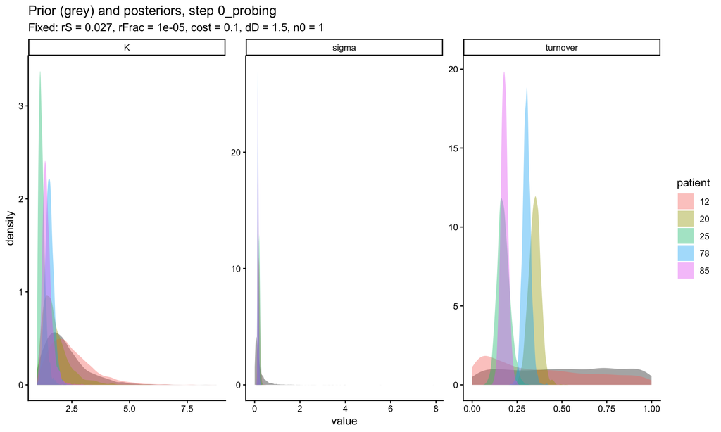

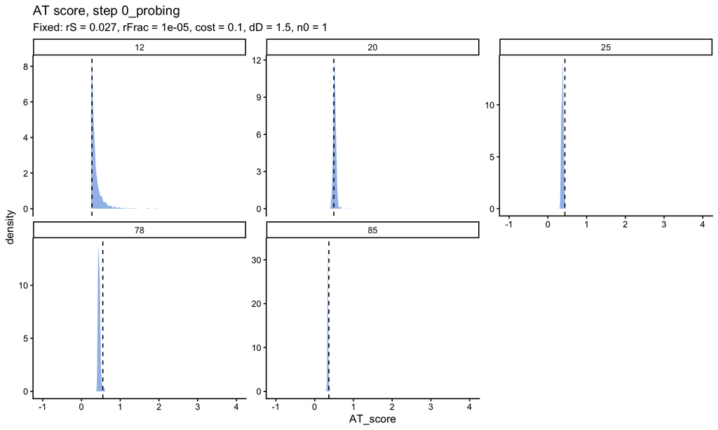

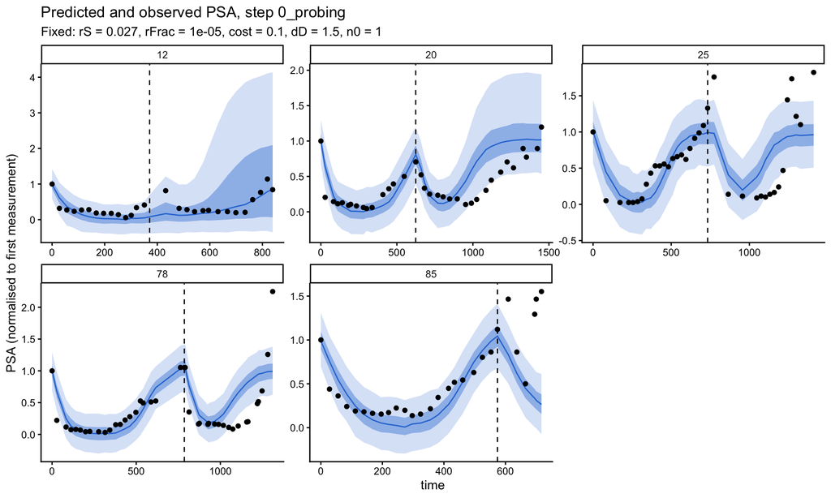

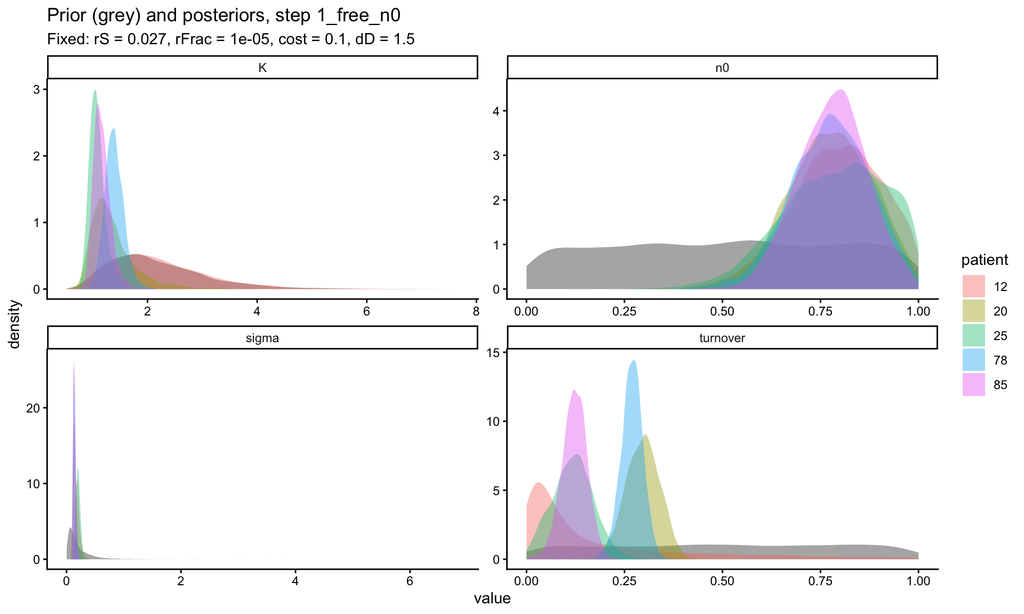

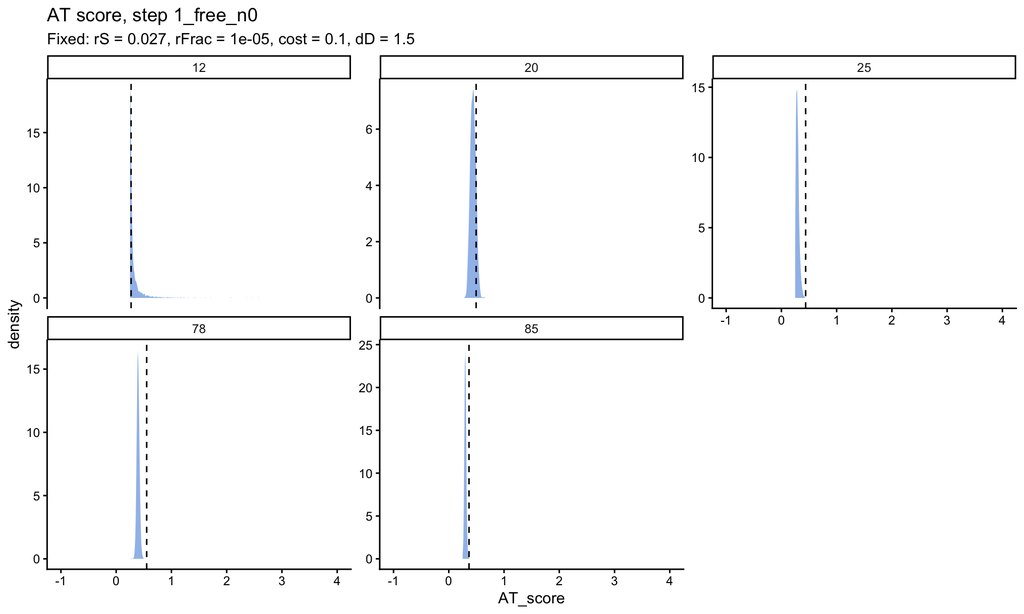

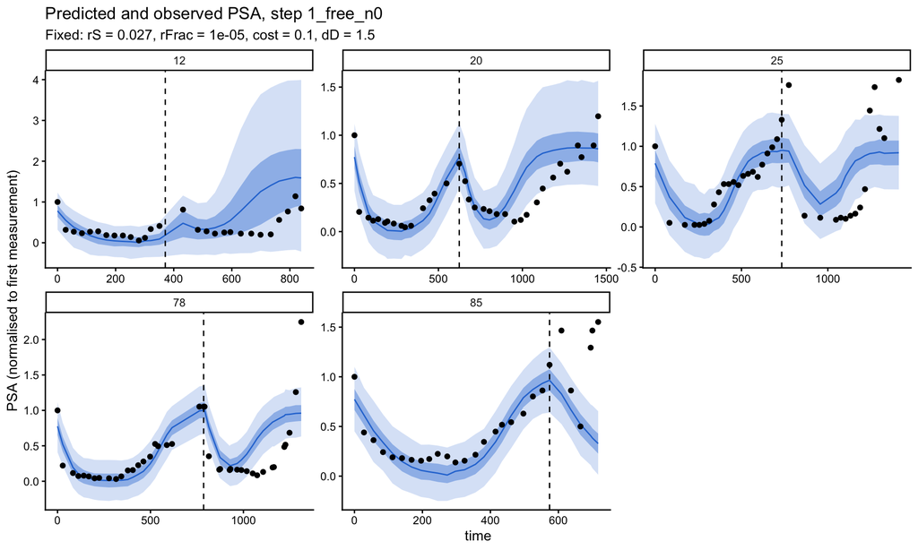

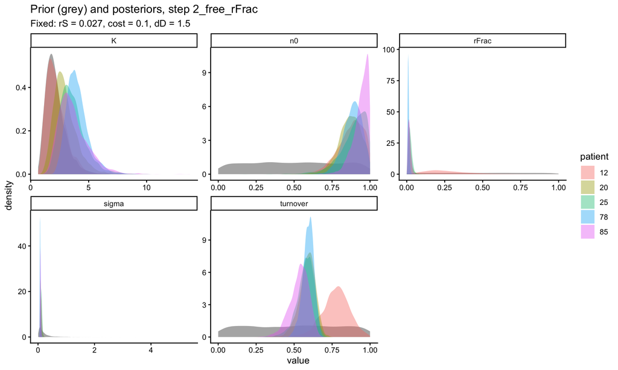

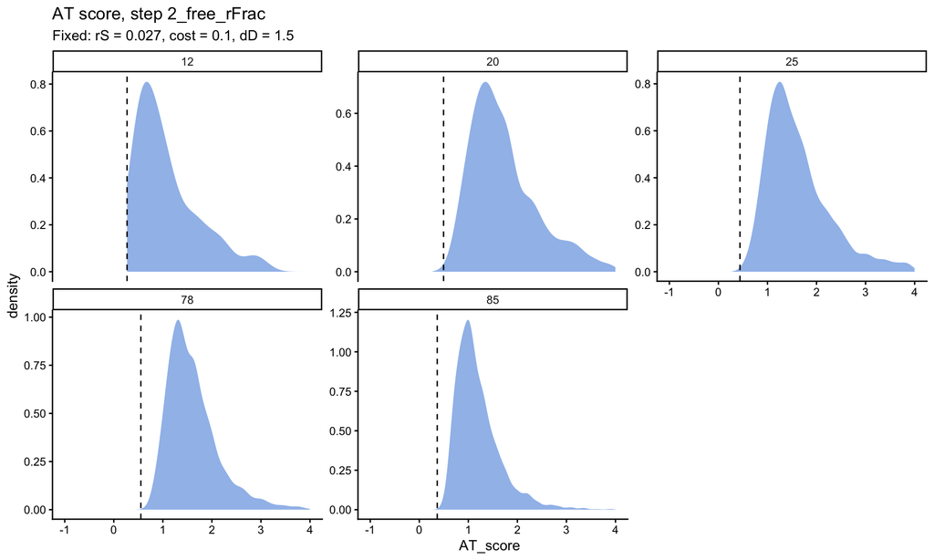

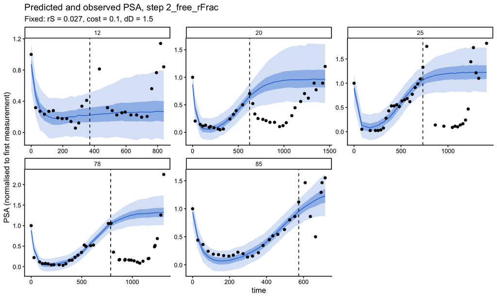

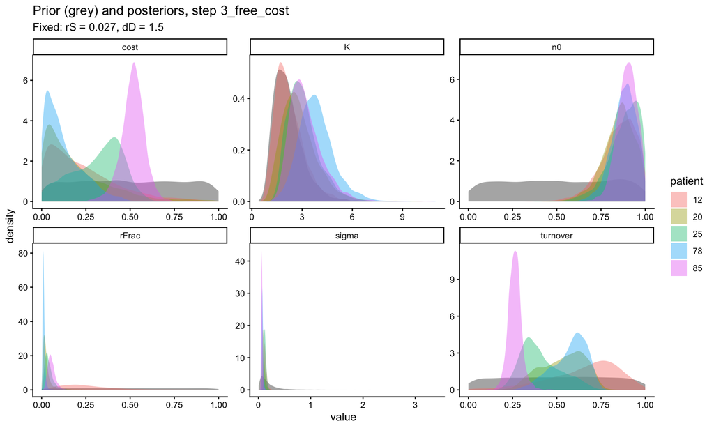

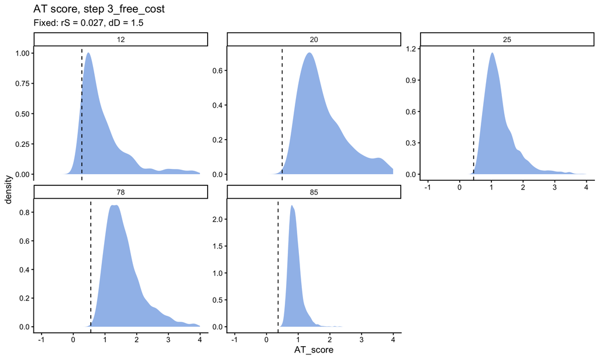

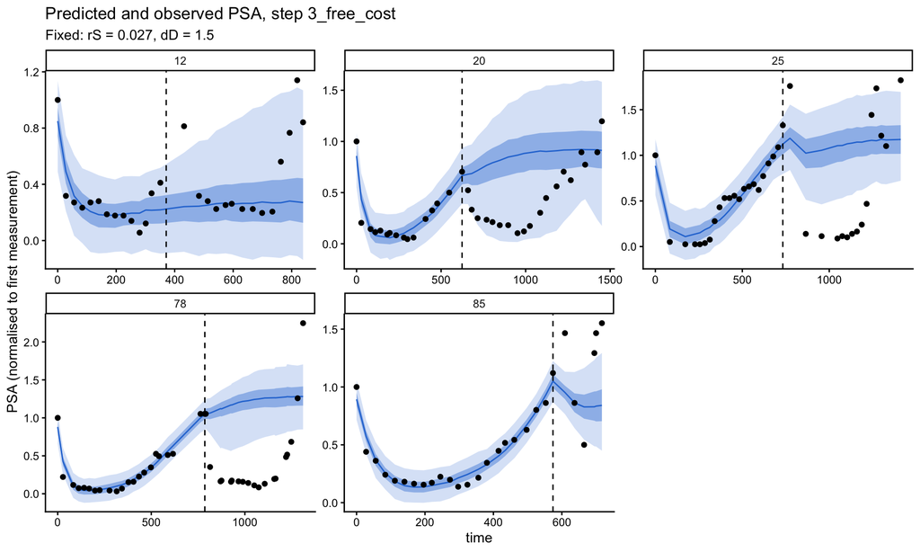

[6 more figures not shown]

```r
for (step in names(step_fits)) {
  step_fit <- step_fits[[step]]
  if (is.null(step_fit)) next
  fixed_vals <- step_fit$settings$fixed_vals
  free <- setdiff(params, names(fixed_vals))
  fixed_text <- if (length(fixed_vals)) paste(names(fixed_vals), unlist(fixed_vals), sep = " = ", collapse = ", ") else "none"

  #free parameters, prior in grey and one colour per patient
  prior_long <- draw_prior(step_fit$settings$priors, fixed_vals) |>
    select(all_of(free)) |>
    pivot_longer(everything(), names_to = "parameter")
  params_plot <- step_fit$draws |>
    select(patient, all_of(free)) |>
    pivot_longer(-patient, names_to = "parameter") |>
    ggplot(aes(value)) +
    geom_density(data = prior_long, fill = "grey70", colour = NA) +
    geom_density(aes(fill = factor(patient)), alpha = .4, colour = NA) +
    facet_wrap(~ parameter, scales = "free") +
    theme_classic() +
    labs(title = paste("Prior (grey) and posteriors, step", step), subtitle = paste("Fixed:", fixed_text), fill = "patient")
  print(params_plot)

  #AT score on draws where progression is possible, with the paper's value as a dashed line
  at_plot <- step_fit$draws |>
    filter(can_progress, between(AT_score, -4, 4)) |>
    ggplot(aes(AT_score)) +
    geom_density(fill = "#2a78d6", alpha = .5, colour = NA) +
    geom_vline(data = paper_at_scores, aes(xintercept = AT_score), linetype = "dashed") +
    facet_wrap(~ patient, scales = "free_y") +
    coord_cartesian(xlim = c(-1, 4)) +
    theme_classic() +
    labs(title = paste("AT score, step", step), subtitle = paste("Fixed:", fixed_text))
  print(at_plot)

  #predicted PSA with 50% (dark) and 95% (light) intervals, observed PSA as points
  #dashed line is the end of the fitted first cycle, after it the model is predicting
  trajectory_plot <- step_fit$trajectories |>
    ggplot(aes(time)) +
    geom_ribbon(aes(ymin = q2.5, ymax = q97.5), fill = "#2a78d6", alpha = .2) +
    geom_ribbon(aes(ymin = q25, ymax = q75), fill = "#2a78d6", alpha = .4) +
    geom_line(aes(y = median), colour = "#2a78d6") +
    geom_point(aes(y = PSA)) +
    geom_vline(data = distinct(step_fit$trajectories, patient, cycle1_end), aes(xintercept = cycle1_end), linetype = "dashed") +
    facet_wrap(~ patient, scales = "free") +
    theme_classic() +
    labs(title = paste("Predicted and observed PSA, step", step), subtitle = paste("Fixed:", fixed_text),
         y = "PSA (normalised to first measurement)")
  print(trajectory_plot)
}
```

### Across steps

```r
#share of draws where progression is possible, next to the sampler diagnostics
step_diagnostics <- map_dfr(step_fits, \(x) x$diagnostics |>
                              left_join(x$draws |> group_by(patient) |> summarise(kept = mean(can_progress)), by = "patient"),
                            .id = "step")
knitr::kable(step_diagnostics, digits = 3)
```

| step | patient | divergences | max_rhat | kept |
| --- | --- | --- | --- | --- |
| 0_probing | 12 | 0 | 1.001 | 0.558 |
| 0_probing | 20 | 0 | 1.004 | 0.265 |
| 0_probing | 25 | 0 | 1.002 | 0.018 |
| 0_probing | 78 | 0 | 1.002 | 0.043 |
| 0_probing | 85 | 0 | 1.003 | 0.290 |
| 1_free_n0 | 12 | 0 | 1.002 | 0.843 |
| 1_free_n0 | 20 | 0 | 1.003 | 0.372 |
| 1_free_n0 | 25 | 0 | 1.003 | 0.448 |
| 1_free_n0 | 78 | 0 | 1.003 | 0.609 |
| 1_free_n0 | 85 | 0 | 1.003 | 0.709 |
| 2_free_rFrac | 12 | 0 | 1.003 | 0.009 |
| 2_free_rFrac | 20 | 0 | 1.004 | 0.370 |
| 2_free_rFrac | 25 | 0 | 1.004 | 0.800 |
| 2_free_rFrac | 78 | 0 | 1.005 | 0.957 |
| 2_free_rFrac | 85 | 0 | 1.005 | 0.859 |
| 3_free_cost | 12 | 0 | 1.004 | 0.050 |
| 3_free_cost | 20 | 0 | 1.007 | 0.340 |
| 3_free_cost | 25 | 0 | 1.003 | 0.741 |
| 3_free_cost | 78 | 0 | 1.002 | 0.915 |
| 3_free_cost | 85 | 0 | 1.002 | 0.909 |
| 4_free_dD | 12 | 0 | 1.005 | 0.045 |
| 4_free_dD | 20 | 0 | 1.008 | 0.609 |
| 4_free_dD | 25 | 0 | 1.003 | 0.906 |
| 4_free_dD | 78 | 0 | 1.002 | 0.970 |
| 4_free_dD | 85 | 0 | 1.005 | 0.936 |
| 5_free_rS | 12 | 0 | 1.005 | 0.033 |
| 5_free_rS | 20 | 0 | 1.004 | 0.614 |
| 5_free_rS | 25 | 1 | 1.003 | 0.896 |
| 5_free_rS | 78 | 0 | 1.005 | 0.974 |
| 5_free_rS | 85 | 1 | 1.002 | 0.934 |

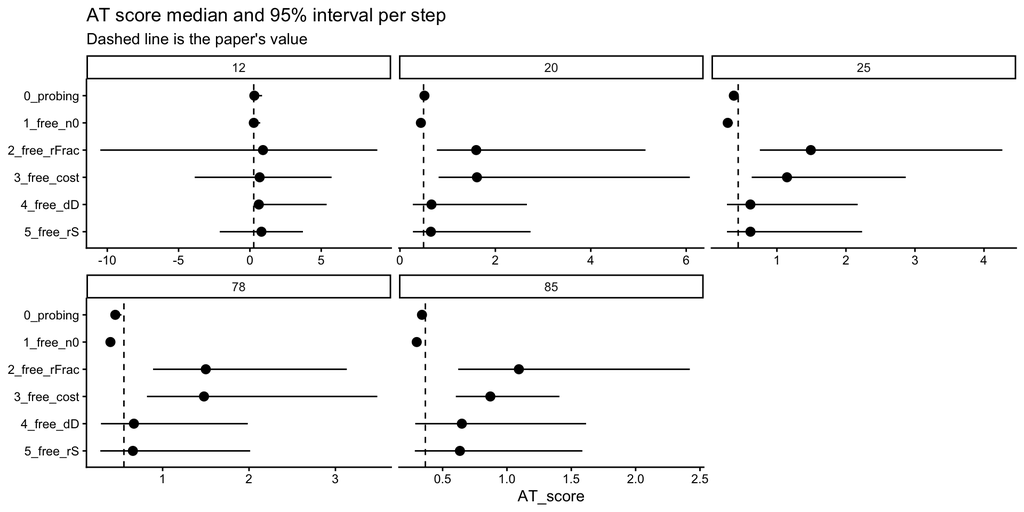

```r
at_steps <- map_dfr(step_fits, \(x) x$draws |>
                      filter(can_progress, is.finite(AT_score)) |>
                      group_by(patient) |>
                      median_qi(AT_score),
                    .id = "step") |>
  mutate(step = factor(step, rev(names(steps))))

ggplot(at_steps, aes(AT_score, step, xmin = .lower, xmax = .upper)) +
  geom_pointrange() +
  geom_vline(data = paper_at_scores, aes(xintercept = AT_score), linetype = "dashed") +
  facet_wrap(~ patient, scales = "free_x") +
  theme_classic() +
  labs(title = "AT score median and 95% interval per step", subtitle = "Dashed line is the paper's value", y = NULL)
```

## Full history, all parameters free

Same model, priors and sampler settings as step 5 (nothing fixed), but fitted to every cycle instead of only the first. The question is whether the later cycles identify what the first cycle could not (rS, K, rFrac, cost), and how that moves the AT score.

```r
fit_patients(probing_ids, stan_file = here::here("stan/model_switchable.stan"), priors = make_priors(),
             fixed_vals = list(), first_cycle = FALSE,
             out_dir = here::here("fits/full_history_free"),
             chains = 4, parallel_chains = 4, seed = 1, refresh = 500, adapt_delta = .95)
```

```r
#results hidden because generate_quantities prints cmdstan progress
full_free  <- read_step("full_history_free", here::here("fits/full_history_free"))
first_free <- step_fits[["5_free_rS"]]
```

```r
fit_colours <- c("prior" = "grey70", "first cycle" = "#2a78d6", "full history" = "#eb6834")

#sampler diagnostics and share of draws where progression is possible, both fits
bind_rows(`first cycle` = first_free$diagnostics, `full history` = full_free$diagnostics, .id = "fit") |>
  left_join(bind_rows(`first cycle` = first_free$draws, `full history` = full_free$draws, .id = "fit") |>
              group_by(fit, patient) |> summarise(kept = mean(can_progress), .groups = "drop"),
            by = c("fit", "patient")) |>
  arrange(patient, fit) |>
  knitr::kable(digits = 3)
```

| fit | patient | divergences | max_rhat | kept |
| --- | --- | --- | --- | --- |
| first cycle | 12 | 0 | 1.005 | 0.033 |
| full history | 12 | 0 | 1.004 | 0.035 |
| first cycle | 20 | 0 | 1.004 | 0.614 |
| full history | 20 | 0 | 1.006 | 0.780 |
| first cycle | 25 | 1 | 1.003 | 0.896 |
| full history | 25 | 0 | 1.012 | 0.332 |
| first cycle | 78 | 0 | 1.005 | 0.974 |
| full history | 78 | 73 | 1.093 | 0.038 |
| first cycle | 85 | 1 | 1.002 | 0.934 |
| full history | 85 | 1 | 1.006 | 0.994 |

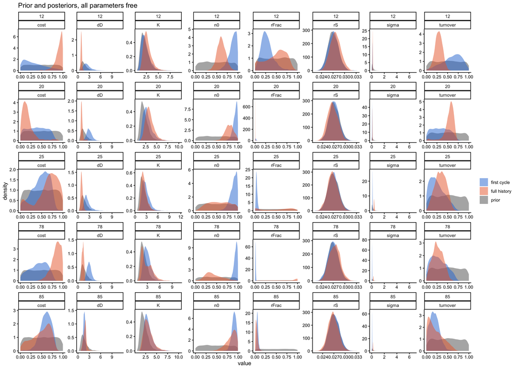

```r
#prior (drawn in every row) and the two posteriors, one row per patient
free_draws <- bind_rows(`first cycle` = first_free$draws, `full history` = full_free$draws, .id = "fit") |>
  select(fit, patient, all_of(params)) |>
  pivot_longer(all_of(params), names_to = "parameter")
prior_long <- draw_prior(full_free$settings$priors, list()) |>
  pivot_longer(everything(), names_to = "parameter")

ggplot(free_draws, aes(value)) +
  geom_density(data = prior_long, aes(fill = "prior"), colour = NA) +
  geom_density(aes(fill = fit), alpha = .5, colour = NA) +
  facet_wrap(patient ~ parameter, ncol = length(params), scales = "free") + #free per panel, the tight rS prior flattens a shared y axis
  scale_fill_manual(values = fit_colours) +
  theme_classic() +
  labs(title = "Prior and posteriors, all parameters free", fill = NULL)
```

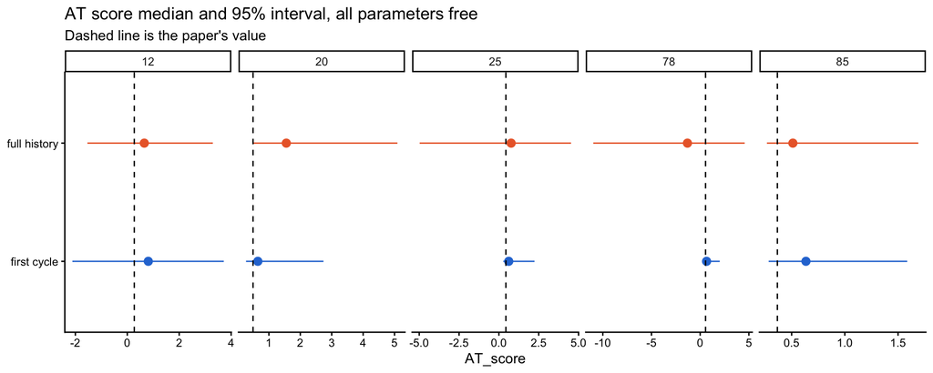

```r
#AT score on draws where progression is possible, with the paper's value as a dashed line
bind_rows(`first cycle` = first_free$draws, `full history` = full_free$draws, .id = "fit") |>
  filter(can_progress, is.finite(AT_score)) |>
  group_by(fit, patient) |>
  median_qi(AT_score) |>
  ggplot(aes(AT_score, fit, xmin = .lower, xmax = .upper, colour = fit)) +
  geom_pointrange() +
  geom_vline(data = paper_at_scores, aes(xintercept = AT_score), linetype = "dashed") +
  facet_wrap(~ patient, scales = "free_x", nrow = 1) +
  scale_colour_manual(values = fit_colours, guide = "none") +
  theme_classic() +
  labs(title = "AT score median and 95% interval, all parameters free", subtitle = "Dashed line is the paper's value", y = NULL)
```

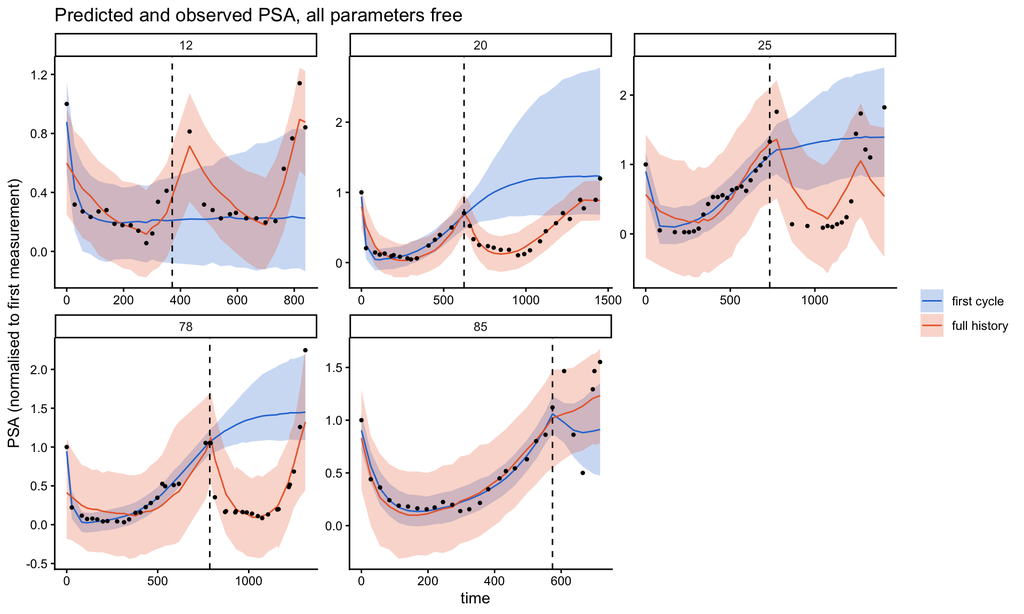

```r
#predicted PSA with 95% intervals from both fits, observed PSA as points
#dashed line is the end of the first cycle, after it the first cycle fit is predicting
bind_rows(`first cycle` = first_free$trajectories, `full history` = full_free$trajectories, .id = "fit") |>
  ggplot(aes(time)) +
  geom_ribbon(aes(ymin = q2.5, ymax = q97.5, fill = fit), alpha = .25) +
  geom_line(aes(y = median, colour = fit)) +
  geom_point(aes(y = PSA), data = full_free$trajectories, size = .8) +
  geom_vline(data = distinct(full_free$trajectories, patient, cycle1_end), aes(xintercept = cycle1_end), linetype = "dashed") +
  facet_wrap(~ patient, scales = "free") +
  scale_fill_manual(values = fit_colours) +
  scale_colour_manual(values = fit_colours) +
  theme_classic() +
  labs(title = "Predicted and observed PSA, all parameters free", fill = NULL, colour = NULL,
       y = "PSA (normalised to first measurement)")
```

## Questions

I think we will need to place some priors somewhere. Maybe it can be estimated from the data.

How would we know that a digital twin is good enough that we would trust it for medical decisions.